This post explores some characteristics of missing data in PITCHf/x data acquired via [**pitchRx**](https://github.com/cpsievert/pitchRx)

## Get your data into memory

To avoid repeating expensive join operations, I like to compute a table that joins the `"pitch"` table with `"atbat"`.

```r
library("dplyr")
db <- src_sqlite("~/pitchfx/pitchRx.sqlite3")
pa_full <- tbl(db, "pitch") %>%
  left_join(tbl(db, "atbat"), by = c("num", "gameday_link"))
compute(pa_full, name = "pa_full", temporary = FALSE)
```

This table is quite large, but it fits into memory on machines with a decent amount of RAM (it takes up about 5 out of the 8GB on my mac). In general, having your data in memory can **drastically** reduce the computational time of operations. Thus, if you can, `collect()` this table to pull it into R as a data frame.

```r
pa_full <- tbl(db, "pa_full") %>% collect()
dim(pa_full)
```

```
[1] 5348578      74
```

## Exploring missingness

Now that `pa_full` is in memory, let’s compute the proportion of `NA`s (which is `R`’s way of encoding missing values) for each variable broken down by year.

```r
prop_na <- function(x) mean(is.na(x))
nas <- pa_full %>%
  mutate(year = substr(date, 0, 4)) %>%
  group_by(year) %>%
  summarise_each(funs(prop_na))
```

To plot the proportions, we should transform `nas` from “wide form” (where each variable has it’s own column) to “long form” (where variable names are stored in a single column). This is a job for `tidyr::gather()`:

```r
na_tidy <- nas %>%
  tidyr::gather(variable, prop_na, -year) %>%
  # the row_names variable is useless
  filter(variable != "row_names")
```

For visualization purposes, we’ll also want the ordering of the variables to reflect the overall proportion of `NA`s.

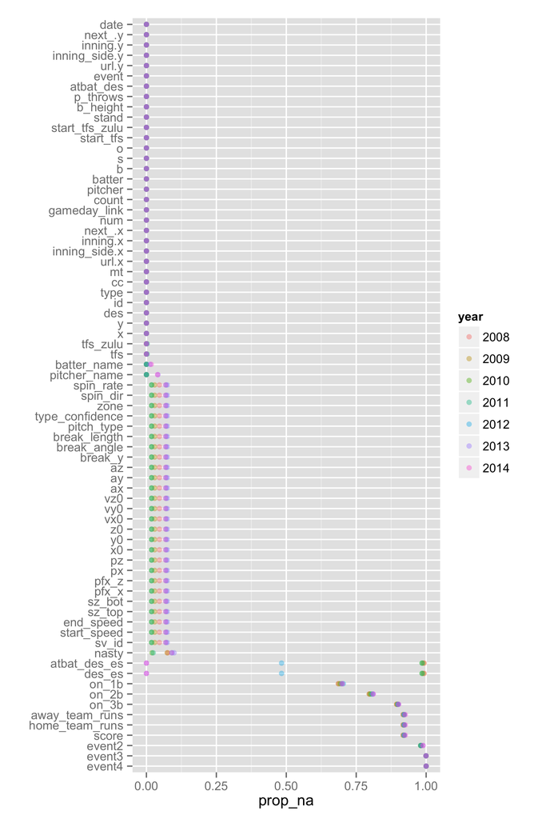

```r
# order variables according to the proportion of NAs
na_sort <- na_tidy %>%
  group_by(variable) %>%
  summarise(avg_na = mean(prop_na)) %>%
  arrange(desc(avg_na))
# reorder the variable factor in na_tidy
na_tidy$variable <- factor(na_tidy$variable, levels = na_sort$variable)
library("ggplot2")
ggplot(data = na_tidy, aes(x = variable, y = prop_na, color = year)) +
  geom_point(alpha = 0.4) + coord_flip() + xlab("")
```

I see roughly three different categories of missingness here: (1) nothing missing, (2) partially missing (3) mostly missing.

Thankfully, variables that are mostly missing are that way by design. It’s not very intuitive that `away_team_runs`, `home_team_runs`, or `score` would have missing values, but for some reason, MLBAM programmers decided to populate these variables only when a run was scored during that at-bat/pitch. For modeling purposes, you probably want to replace `NA` with 0 in these columns, but you may also prefer to have these columns have the running total instead (in that case, you can use [this](https://github.com/cpsievert/pitchRx/issues/17)). It makes sense that `event2`, `event2`, & `event4` are mostly missing since most at-bat outcomes can be adequately summarised with a single event (but some need an additional tag like wild-pitch, error, and/or pick-off). We can also see that spanish translations of atbat & pitch descriptions (`des_es` & `atbat_des_es`) started in 2012.

```r
game <- tbl(db, "game") %>%
  mutate(reg = as.integer(game_type == "R")) %>%
  select(gameday_link, reg) %>%
  collect()
# unfortunately we have to prepend "gid_" for this variable
# to match the one
game <- game %>%
  mutate(gameday_link = paste0("gid_", gameday_link))
pa_full <- pa_full %>%
  left_join(game, by = "gameday_link")
```

[figure not shown]